# Práctica 09 - Análisis de sentimientos

### Introducción a la práctica

Uno de los enfoques más ampliamente usados en computación para saber la polaridad positiva o negativa de una opinión, expresada en un cuerpo de texto, es el análisis de sentimientos [1]. Mediante esta técnica se asigna un valor que está en el rango de -1 a +1 para expresar el grado de opinión negativa o positiva expresada por un autor en un documento. Un valor de -1 significa una opinión completamente negativa acerca de lo que se escribió, un valor +1 se asocia con una opinión totalmente positiva sobre lo escrito, mientras que un 0 significa una opinión plenamente neutral [idem]. El lenguaje R proporciona el paquete SentimentAnalysis [2], que permite realizar análisis de sentimientos en cuerpos de texto, del cual se hace uso en la presente práctica.

### Procedimiento o desarrollo

1.- Ingresa al entorno de desarrollo de R.

2.- Ahora debes indicar a R que usarás el paquete SentimentAnalysis para poder generar análisis de sentimientos. También debe instalarse los paquetes asociados a ese paquete, las cuales son slam , SnowballC , NLP . Por la razón anterior, teclea las siguientes funciones.

```r
# install.packages("slam", type = "binary")
# install.packages('SnowballC', repos='http://cran.us.r-project.org')
# install.packages("NLP")
# install.packages('SentimentAnalysis', repos='http://cran.us.r-project.org')
```

Una vez que instalados los paquetes anteriores, procede a realizar el análisis de sentimientos.

3.- Lo primero que debes hacer es crear el texto que quieres analizar. Teclea el siguiente commando para almacenar un texto en la variable texto . Ese cuerpo de texto contendrá seis líneas de texto.

```r
library(SentimentAnalysis)
# set of reviews
texts <- c("Wow, I really like the new light sabers!", "That book was excellent.", "R is a fantastic language.", "The service in this restaurant was miserable.", "This is neither positive or negative.", "The waiter forget about my dessert -- what poor service!")
```

4.- Lo siguiente a realizar es propiamente el análisis de sentimientos en la variable texto, el cual lo almacenarás en la variable sentir:

```r
setiment <- analyzeSentiment(texts)
```

5.- El resultado del análisis de sentimientos realizado con la función anterior genera valores numéricos, para convertir esos resultados cuantitativos a cualitativos se debe hacer lo siguiente:

```r
convertToDirection(setiment$SentimentQDAP)
```

```
## [1] positive positive positive negative neutral  negative
## Levels: negative neutral positive
```

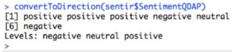

**Figura 1.** Resultado de la función convertToDirection.

### Producto a entregar

Archivo PDF con lo siguiente:

- **a. Respuesta al siguiente cuestionamiento. Considerando los resultados obtenidos en el análisis de sentimientos realizado al documento de la práctica, el cual se dio línea por línea, ¿cuál sería el sentimiento del cuerpo de texto completo?**

Cabe recalcar que cada una de las opiniones parecen ser de contextos diferentes, sin embargo, en el output hay una mayoria de opiniones positivas, por lo que se puede decir que ese conjunto de textos es positivo. También se pueden juntar todos los textos en una sola string y pasarlos a la función analyzeSentiment, de la siguiente forma:

```r
complete_text <- ("Wow, I really like the new light sabers!. That book was excellent.R is a fantastic language. The service in this restaurant was miserable.This is neither positive or negative. The waiter forget about my dessert -- what poor service!")

setiment <- analyzeSentiment(complete_text)

convertToDirection(setiment$SentimentQDAP)
```

```
## [1] positive
## Levels: negative neutral positive
```

- **b. Modifica la lista de adjetivos utilizados en la cadena texto, usada en la práctica, y calcula el análisis de sentimientos. Interpreta los resultados.**

```r
texts_v2 <- c("Wow, I really hate the new light sabers!", "That book was so boring", "R is an unpopular language.", "The service in this restaurant was aceptable.", "This is neither negative or positive.", "The waiter forget about my dessert -- but it doesn´t matter the food was great!")

setiment <- analyzeSentiment(texts_v2)

convertToDirection(setiment$SentimentQDAP)
```

```
## [1] neutral  negative negative neutral  neutral  neutral
## Levels: negative neutral positive
```

El algoritmo solo acertó 3/6. Debió haber respondido con: ❌negative ✅negative ❌neutral ✅neutral ✅neutral ❌positive

- **c. Investiga, en la fuente de información que consideres pertinente, qué tendrías que hacer para analizar sentimientos en un cuerpo de texto escrito en español.**

```r
library(syuzhet)

es_text <- c("Los tacos saben bien pero la barbacoa esta seca.", "El adapatador deja de funcionar en ambientes cálidos.", "odio la barra.", "amo la barra.")

sentiments <- get_nrc_sentiment(es_text, lang="spanish")
head(sentiments)
```

|  | anger | anticipation | disgust | fear | joy | sadness | surprise | trust | negative | positive |
| --- | --- | --- | --- | --- | --- | --- | --- | --- | --- | --- |
| 1 | 0 | 0 | 0 | 0 | 0 | 0 | 0 | 0 | 0 | 0 |
| 2 | 0 | 0 | 0 | 0 | 0 | 0 | 0 | 0 | 0 | 0 |
| 3 | 1 | 0 | 1 | 2 | 0 | 1 | 0 | 1 | 1 | 1 |
| 4 | 0 | 0 | 0 | 1 | 0 | 0 | 0 | 1 | 0 | 1 |

En el código anterior se usó la libreria syuzhet que cuenta con una amplia cantidad de lenguajes para analizar texto. Por otro lado, también se podría traducir el texto y después interpretarlo con la libreria SentimentAnalysis

- **d. Incluye imágenes con las pantallas de los modelos generados en R.**✅
- **e. Conclusiones del desarrollo de la práctica.**

En mi opinión el análisis de sentiminetos es de las mejores herramientas de ciencia de datos que se pueden usar en el mundo real (más allá de lo académico), ya que siempre es importante recibir un feedback no implicito de como es aceptado un producto / servicio. También es importante buscar una buena libreria o API que funcione en el idioma destinado, ya que con respecto a las librerias usadas arrojaban una cantidad considerable de errores.